# Revision_notes_v4

## Python Lists

| Concept | Description & Syntax |
| --- | --- |
| **Definition** | Data structure written using square brackets `[]`. Allows storage of multiple objects. `my_list = [1, "apple", True]` |
| **Indexing** | Zero-based. First element is at index 0. `my_list[0]` |
| **Negative Indexing** | Access from the end. `-1` is the last element. `my_list[-1]` |
| **Slicing** | Access a range of elements. `list[start:end]`. `my_list[1:3]` |
| **Adding Elements** | `append(item)` adds to the end. `insert(index, item)` adds at a position. `my_list.append("banana")` |
| **Removing Elements** | `pop(index)` removes and returns item. `remove(value)` removes first occurrence. `del list[index]` deletes. `my_list.pop()` |
| **Length** | Returns the number of items. `len(my_list)` |
| **Sorting** | `list.sort()` sorts in-place. `sorted(list)` returns a new sorted list. `my_list.sort()` |

## For Loops

| Concept | Description & Syntax |
| --- | --- |
| **Basic Syntax** | Iterates over a sequence. `for item in sequence:` |
| **Range Function** | Generates a sequence of numbers. `range(start, stop, step)`. `for i in range(5):` |
| **Indentation** | Code inside the loop must be indented (standard is 4 spaces). |

## List Comprehension

| Concept | Description & Syntax |
| --- | --- |
| **Basic** | Concise way to create lists. `[expression for item in iterable]`. `[x**2 for x in range(5)]` |
| **With Condition** | Filter items. `[expression for item in iterable if condition]`. `[x for x in numbers if x % 2 == 0]` |

## Tuples

| Concept | Description & Syntax |
| --- | --- |
| **Definition** | Immutable sequence. Defined with parentheses `()`. `my_tuple = (1, 2, 3)` |
| **Immutability** | Cannot be changed after creation (no append, remove, or assignment). |
| **Unpacking** | Assign tuple values to variables. `a, b, c = my_tuple` |

## PEP 8 (Style Guide)

| Concept | Description & Syntax |
| --- | --- |
| **Indentation** | Use 4 spaces per indentation level. |
| **Naming** | Variables/Functions: `snake_case`. Classes: `CamelCase`. Constants: `UPPER_CASE`. |
| **Whitespace** | Avoid extraneous whitespace. Space after commas, around operators. |

```python
# 1. Lists: Creation and Manipulation
shopping_list = ["apples", "bread", "milk"]
shopping_list.append("eggs")        # Add to end
shopping_list.insert(1, "butter")   # Insert at index 1
removed_item = shopping_list.pop()  # Remove last item ('eggs')

print(f"Shopping List: {shopping_list}")
print(f"First item: {shopping_list[0]}")
print(f"Last item: {shopping_list[-1]}")

# 2. For Loops and Range
print("\n--- Loop Output ---")
for item in shopping_list:
    print(f"I need to buy {item}")

print("\n--- Range Output ---")
for i in range(1, 4): # 1 to 3
    print(f"Count: {i}")

# 3. List Comprehension
numbers = [1, 2, 3, 4, 5]
# Create a new list of squares
squares = [n**2 for n in numbers]
# Filter for even numbers
evens = [n for n in numbers if n % 2 == 0]

print(f"\nNumbers: {numbers}")
print(f"Squares: {squares}")
print(f"Evens: {evens}")

# 4. Tuples (Immutable)
dimensions = (1920, 1080)
width, height = dimensions # Unpacking
print(f"\nScreen Dimensions: {width}x{height}")
# dimensions[0] = 1280 # This would cause a TypeError
```

```
Shopping List: ['apples', 'butter', 'bread', 'milk']
First item: apples
Last item: milk

--- Loop Output ---
I need to buy apples
I need to buy butter
I need to buy bread
I need to buy milk

--- Range Output ---
Count: 1
Count: 2
Count: 3

Numbers: [1, 2, 3, 4, 5]
Squares: [1, 4, 9, 16, 25]
Evens: [2, 4]

Screen Dimensions: 1920x1080
```

# Data Visualization with Matplotlib

## What you need

- One-time install: `pip install matplotlib pandas numpy`
- Imports: `import matplotlib.pyplot as plt`, `import pandas as pd`, `import numpy as np` (np for quick numeric arrays)

## Quick syntax reminders

| Concept | Snippet |
| --- | --- |
| Line plot | `plt.plot(x, y, marker="o")` |
| Scatter plot | `plt.scatter(x, y, color="green", s=100)` |
| Colormap scatter | `plt.scatter(x, y, c=y, cmap="plasma"); plt.colorbar()` |
| Bar chart | `plt.bar(labels, values); plt.grid(axis="y")` |
| Plot from pandas | `df = pd.DataFrame(data); plt.plot(df["Year"], df["Sales"], marker="o")` |

## Small tips

- Always add a title and axis labels; keep units obvious.
- Use `plt.grid(True)` to make values easier to read.
- Call `plt.tight_layout()` when using subplots; finish with `plt.show()`.
- Save if needed: `plt.savefig("plot.png")` before `plt.show()`.

## NumPy quick notes

- Import convention: `import numpy as np`
- List to array + vectorised ops: `arr = np.array([1, 4, 9, 16]); arr * 2 # [ 2 8 18 32 ]`
- Apply a function across elements: `np.sqrt(arr) # [1. 2. 3. 4.]`
- Fast sequences: `np.arange(0, 11, 2)` or `np.linspace(0, 10, 6)` for evenly spaced values
- Zeros array: `np.zeros(5) # [0. 0. 0. 0. 0.]`
- Range with step: `np.arange(0, 1, 0.2) # [0. 0.2 0.4 0.6 0.8]`
- Random ints (dice): `np.random.randint(1, 7, 5)` → 5 rolls from 1–6
- Random normal: `np.random.normal(100, 5, 4)` → 4 samples with mean 100, std 5
- Arrays behave like math vectors (elementwise add/multiply); prefer arrays when doing numeric work before plotting.

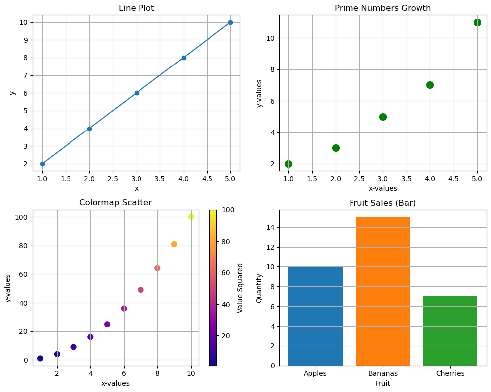

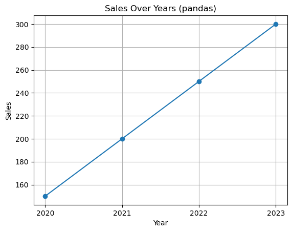

```
Array: [ 1  4  9 16]
Array * 2: [ 2  8 18 32]
Sqrt: [1. 2. 3. 4.]
Zeros: [0. 0. 0. 0. 0.]
Arange step 0.2: [0.  0.2 0.4 0.6 0.8]
Random ints (dice 5 rolls 1-6): [1 6 2 1 2]
Random normal (mean=100, sd=5, size=4): [107.55146471 101.18403889 108.60696214 102.09660958]
```

```python
import numpy as np
import matplotlib.pyplot as plt
import pandas as pd

# 1) Line plot
x = [1, 2, 3, 4, 5]
y = [2, 4, 6, 8, 10]
plt.figure(figsize=(10, 8))
plt.subplot(2, 2, 1)
plt.plot(x, y, marker="o")
plt.title("Line Plot")
plt.xlabel("x")
plt.ylabel("y")
plt.grid(True)

# 2) Scatter plot
x_values = [1, 2, 3, 4, 5]
y_values = [2, 3, 5, 7, 11]
plt.subplot(2, 2, 2)
plt.scatter(x_values, y_values, color="green", s=100)
plt.title("Prime Numbers Growth")
plt.xlabel("x-values")
plt.ylabel("y-values")
plt.grid(True)

# 3) Scatter with colormap
x_cm = list(range(1, 11))
y_cm = [value**2 for value in x_cm]
plt.subplot(2, 2, 3)
scatter = plt.scatter(x_cm, y_cm, c=y_cm, cmap="plasma", s=60)
plt.colorbar(scatter, label="Value Squared")
plt.title("Colormap Scatter")
plt.xlabel("x-values")
plt.ylabel("y-values")
plt.grid(True)

# 4) Bar chart
plt.subplot(2, 2, 4)
categories = ["Apples", "Bananas", "Cherries"]
values = [10, 15, 7]
plt.bar(categories, values, color=["#1f77b4", "#ff7f0e", "#2ca02c"])
plt.title("Fruit Sales (Bar)")
plt.xlabel("Fruit")
plt.ylabel("Quantity")
plt.grid(axis="y")

plt.tight_layout()
plt.show()

# Simple pandas example
data = {"Year": [2020, 2021, 2022, 2023], "Sales": [150, 200, 250, 300]}
df = pd.DataFrame(data)
plt.plot(df["Year"], df["Sales"], marker="o")
plt.title("Sales Over Years (pandas)")
plt.xlabel("Year")
plt.ylabel("Sales")
plt.xticks(df["Year"])
plt.grid(True)
plt.show()

# NumPy examples from Week 3 slides
arr = np.array([1, 4, 9, 16])
print("Array:", arr)
print("Array * 2:", arr * 2)
print("Sqrt:", np.sqrt(arr))
print("Zeros:", np.zeros(5))
print("Arange step 0.2:", np.arange(0, 1, 0.2))
print("Random ints (dice 5 rolls 1-6):", np.random.randint(1, 7, 5))
print("Random normal (mean=100, sd=5, size=4):", np.random.normal(100, 5, 4))
```

# Control Flow and Dictionaries

## Conditional Statements

| Concept | Description & Syntax |
| --- | --- |
| **If Statement** | Executes code if condition is True. `if age >= 18:` |
| **Elif / Else** | Handle alternative conditions. `elif age < 13:` `else:` |
| **Comparison Operators** | `==` (equal), `!=` (not equal), `>`, `<`, `>=`, `<=` |
| **Logical Operators** | `and` (both true), `or` (one true), `not` (inverse) |

## Dictionaries

| Concept | Description & Syntax |
| --- | --- |
| **Definition** | Key-value pairs in curly braces `{}`. Keys must be unique/immutable. `user = {'name': 'Alice', 'age': 25}` |
| **Accessing** | Use key in square brackets. `user['name']` |
| **Get Method** | Safe access (returns None if key missing). `user.get('height')` |
| **Adding/Updating** | Assign value to key. `user['city'] = 'London'` |
| **Removing** | `pop(key)` removes item. `del dict[key]` deletes. `user.pop('age')` |
| **Looping** | Iterate keys, values, or items. `for k, v in user.items():` |

## While Loops & Input

| Concept | Description & Syntax |
| --- | --- |
| **While Loop** | Repeats while condition is True. `while count < 5:` |
| **Break** | Exits the loop immediately. `if x == 'quit': break` |
| **Continue** | Skips to the next iteration. |
| **User Input** | Pauses program to get string from user. `name = input("Enter name: ")` |
| **Type Conversion** | Convert input (string) to other types. `age = int(input("Age: "))` |

```python
# 1. Control Flow (If/Elif/Else)
age = 20
if age >= 18:
    status = "Adult"
elif age >= 13:
    status = "Teenager"
else:
    status = "Child"
print(f"Age {age}: {status}")

# 2. Dictionary Operations
student = {'name': 'Emma', 'course': 'Business', 'grades': [85, 90, 88]}

# Accessing and Updating
print(f"Student: {student['name']}")
student['grade_avg'] = sum(student['grades']) / len(student['grades']) # Add new key
print(f"Average Grade: {student['grade_avg']:.2f}")

# Looping through a dictionary
print("Student Details:")
for key, value in student.items():
    print(f"  - {key}: {value}")

# 3. While Loop (Counter Example)
# (Using a counter instead of input() to allow 'Run All' without blocking)
count = 3
print("Starting countdown:")
while count > 0:
    print(f"  {count}...")
    count -= 1
print("Liftoff!")
```

```
Age 20: Adult
Student: Emma
Average Grade: 87.67
Student Details:
  - name: Emma
  - course: Business
  - grades: [85, 90, 88]
  - grade_avg: 87.66666666666667
Starting countdown:
  3...
  2...
  1...
Liftoff!
```

# Functions

## Function Basics

| Concept | Description & Syntax |
| --- | --- |
| **Definition** | Block of reusable code. Defined with `def`. `def my_func():` |
| **Parameters** | Variables passed into function. `def greet(name):` |
| **Arguments** | Values sent to function when called. `greet("Alice")` |
| **Return** | Sends a result back to the caller. `return x + y` |
| **Docstring** | Documentation string explaining the function. `"""Description"""` |

## Advanced Arguments

| Concept | Description & Syntax |
| --- | --- |
| **Default Args** | Parameter has a default value if not provided. `def power(base, exp=2):` |
| **Keyword Args** | Arguments passed by name. `func(name="Bob", age=30)` |
| **`*args`** | Variable number of positional arguments (tuple). `def sum_all(*args):` |
| **`**kwargs`** | Variable number of keyword arguments (dictionary). `def config(**kwargs):` |

```python
# 1. Basic Function with Return
def calculate_area(length, width):
    """Returns the area of a rectangle."""
    return length * width

area = calculate_area(10, 5)
print(f"Area: {area}")

# 2. Default Arguments & Keyword Arguments
def greet(name, greeting="Hello"):
    return f"{greeting}, {name}!"

print(greet("Alice"))             # Uses default
print(greet("Bob", greeting="Hi")) # Overrides default

# 3. *args (Variable Positional Arguments)
def sum_numbers(*args):
    """Sums any number of arguments."""
    return sum(args)

print(f"Sum: {sum_numbers(1, 2, 3, 4, 5)}")

# 4. **kwargs (Variable Keyword Arguments)
def print_info(**kwargs):
    for key, value in kwargs.items():
        print(f"{key}: {value}")

print_info(name="Charlie", age=28, city="Paris")
```

```
Area: 50
Hello, Alice!
Hi, Bob!
Sum: 15
name: Charlie
age: 28
city: Paris
```

# Object-Oriented Programming (OOP)

## Core Concepts

| Concept | Description & Syntax |
| --- | --- |
| **Class** | Blueprint for creating objects. `class Car:` |
| **Object** | Instance of a class. `my_car = Car()` |
| **`__init__`** | Constructor method, runs when object is created. `def __init__(self, make):` |
| **`self`** | Reference to the current instance. Used to access attributes/methods. `self.make = make` |
| **Attributes** | Variables belonging to an object. `self.color = "Red"` |
| **Methods** | Functions belonging to an object. `def drive(self):` |
| **`__str__`** | String representation of the object (for printing). `def __str__(self): return "Car"` |

```python
# 1. Defining a Class
class Student:
    def __init__(self, name, student_id):
        self.name = name          # Attribute
        self.student_id = student_id
        self.grades = []          # Default attribute

    def add_grade(self, grade):   # Method
        self.grades.append(grade)

    def average_grade(self):
        if not self.grades:
            return 0
        return sum(self.grades) / len(self.grades)

    def __str__(self):            # String representation
        return f"Student: {self.name} (ID: {self.student_id})"

# 2. Creating Objects (Instances)
s1 = Student("Alice", "S001")
s2 = Student("Bob", "S002")

# 3. Using Methods
s1.add_grade(85)
s1.add_grade(90)
s2.add_grade(78)

print(s1)  # Uses __str__
print(f"Alice's Average: {s1.average_grade():.2f}")
print(f"Bob's Average: {s2.average_grade():.2f}")
```

```
Student: Alice (ID: S001)
Alice's Average: 87.50
Bob's Average: 78.00
```

# Files and Exceptions

## File Handling (Standard `open`)

| Concept | Description & Syntax |
| --- | --- |
| **Opening Files** | Use `with open(filename, mode) as file:` to ensure proper closing. |
| **Modes** | `'r'` (read), `'w'` (write - overwrites), `'a'` (append). |
| **Reading** | `file.read()` (all), `file.readlines()` (list of lines), `for line in file:` (iterate). |
| **Writing** | `file.write(string)` |

## JSON Handling

| Concept | Description & Syntax |
| --- | --- |
| **Importing** | `import json` |
| **Saving (Dump)** | `json.dump(data, file)` or `json.dumps(data)` (to string). |
| **Loading (Load)** | `json.load(file)` or `json.loads(string)`. |

## Exception Handling

| Concept | Description & Syntax |
| --- | --- |
| **Try/Except** | Catches errors. `try: ... except FileNotFoundError:` |
| **Multiple Excepts** | `except (ValueError, ZeroDivisionError):` |
| **Else** | Runs if NO exception occurs. |
| **Finally** | Runs always (cleanup). |

```python
import json

# 1. Reading from a File (with Error Handling)
try:
    # Create a dummy file first for demonstration
    with open("animals.txt", "w") as f:
        f.write("Cat\nDog\nElephant")

    with open("animals.txt", "r") as file:
        animals_list = [line.strip() for line in file]
except FileNotFoundError:
    print("The file 'animals.txt' was not found.")
else:
    print("Animals found:", animals_list)

# 2. Writing and Appending
foods = ["Pizza", "Sushi", "Tacos"]
with open("favourites.txt", "w") as file:
    for food in foods:
        file.write(food + "\n")

with open("favourites.txt", "a") as file:
    file.write("Ice Cream\n")

print("\nFavourites saved.")

# 3. JSON Storage
user_data = {"username": "Alice", "score": 95}
with open("user.json", "w") as file:
    file.write(json.dumps(user_data))

# Loading JSON
try:
    with open("user.json") as file:
        content = file.read()
        data = json.loads(content)
        print(f"\nLoaded JSON: User {data['username']} has score {data['score']}")
except FileNotFoundError:
    pass

# 4. Exception Handling (ZeroDivision)
def safe_divide(a, b):
    try:
        return a / b
    except ZeroDivisionError:
        print("Error: Cannot divide by zero.")
        return None

print("\nDivision Test:", safe_divide(10, 0))
```

```
Animals found: ['Cat', 'Dog', 'Elephant']

Favourites saved.

Loaded JSON: User Alice has score 95
Error: Cannot divide by zero.

Division Test: None
```

# Comprehensive Revision Example

This example integrates key concepts from the course into a single application:

```python
import json
import matplotlib.pyplot as plt

class SalesManager:
    def __init__(self, filename="sales_data.json"):
        self.filename = filename
        self.sales = [] # List of dictionaries

    def add_sale(self, product, amount, quantity):
        """Adds a sale record."""
        sale = {
            "product": product,
            "amount": amount,
            "quantity": quantity
        }
        self.sales.append(sale)

    def save_data(self):
        """Saves sales data to a JSON file."""
        with open(self.filename, 'w') as file:
            json.dump(self.sales, file, indent=4)
        print(f"Data saved to {self.filename}")

    def load_data(self):
        """Loads data from file if it exists."""
        try:
            with open(self.filename, 'r') as file:
                self.sales = json.load(file)
            print(f"Data loaded from {self.filename}")
        except FileNotFoundError:
            print("No existing data found. Starting fresh.")

    def get_total_revenue(self):
        """Calculates total revenue."""
        total = 0
        for sale in self.sales:
            total += sale['amount'] * sale['quantity']
        return total

    def get_product_summary(self):
        """Returns a dictionary of total revenue per product."""
        summary = {}
        for sale in self.sales:
            prod = sale['product']
            revenue = sale['amount'] * sale['quantity']
            if prod in summary:
                summary[prod] += revenue
            else:
                summary[prod] = revenue
        return summary

    def plot_revenue(self):
        """Plots revenue per product."""
        summary = self.get_product_summary()
        products = list(summary.keys())
        revenues = list(summary.values())

        plt.figure(figsize=(8, 5))
        plt.bar(products, revenues, color='skyblue')
        plt.title("Total Revenue by Product")
        plt.xlabel("Product")
        plt.ylabel("Revenue (£)")
        plt.show()

# --- Main Execution ---
if __name__ == '__main__':
    print("--- Running Sales Application ---")
    app = SalesManager("my_shop_sales.json")

    # Try loading existing data
    app.load_data()

    # Add some sample data
    app.add_sale("Coffee", 3.50, 10)
    app.add_sale("Tea", 2.50, 15)
    app.add_sale("Cake", 4.00, 5)

    # Calculate and print revenue
    print(f"Total Revenue: £{app.get_total_revenue():.2f}")

    # Save data to file
    app.save_data()

    # Uncomment the line below to see the plot
    # app.plot_revenue()
```

```
--- Running Sales Application ---
No existing data found. Starting fresh.
Total Revenue: £92.50
Data saved to my_shop_sales.json
```